# Assignment-5

Harika

2023-12-03

Pre-processing the Data below:

```r
Cereals <- read.csv("C:/Users/Harika/Downloads/Cereals.csv")
Cereals_Data <- read.csv("C:/Users/Harika/Downloads/Cereals.csv")
str(Cereals)
```

```
## 'data.frame':    77 obs. of  16 variables:
##  $ name    : chr  "100%_Bran" "100%_Natural_Bran" "All-Bran" "All-Bran_with_Extra_Fiber" ...
##  $ mfr     : chr  "N" "Q" "K" "K" ...
##  $ type    : chr  "C" "C" "C" "C" ...
##  $ calories: int  70 120 70 50 110 110 110 130 90 90 ...
##  $ protein : int  4 3 4 4 2 2 2 3 2 3 ...
##  $ fat     : int  1 5 1 0 2 2 0 2 1 0 ...
##  $ sodium  : int  130 15 260 140 200 180 125 210 200 210 ...
##  $ fiber   : num  10 2 9 14 1 1.5 1 2 4 5 ...
##  $ carbo   : num  5 8 7 8 14 10.5 11 18 15 13 ...
##  $ sugars  : int  6 8 5 0 8 10 14 8 6 5 ...
##  $ potass  : int  280 135 320 330 NA 70 30 100 125 190 ...
##  $ vitamins: int  25 0 25 25 25 25 25 25 25 25 ...
##  $ shelf   : int  3 3 3 3 3 1 2 3 1 3 ...
##  $ weight  : num  1 1 1 1 1 1 1 1.33 1 1 ...
##  $ cups    : num  0.33 1 0.33 0.5 0.75 0.75 1 0.75 0.67 0.67 ...
##  $ rating  : num  68.4 34 59.4 93.7 34.4 ...
```

```r
### structure of the dataset.
```

```r
head(Cereals)
```

```
##                        name mfr type calories protein fat sodium fiber carbo
## 1                 100%_Bran   N    C       70       4   1    130  10.0   5.0
## 2         100%_Natural_Bran   Q    C      120       3   5     15   2.0   8.0
## 3                  All-Bran   K    C       70       4   1    260   9.0   7.0
## 4 All-Bran_with_Extra_Fiber   K    C       50       4   0    140  14.0   8.0
## 5            Almond_Delight   R    C      110       2   2    200   1.0  14.0
## 6   Apple_Cinnamon_Cheerios   G    C      110       2   2    180   1.5  10.5
##   sugars potass vitamins shelf weight cups   rating
## 1      6    280       25     3      1 0.33 68.40297
## 2      8    135        0     3      1 1.00 33.98368
## 3      5    320       25     3      1 0.33 59.42551
## 4      0    330       25     3      1 0.50 93.70491
## 5      8     NA       25     3      1 0.75 34.38484
## 6     10     70       25     1      1 0.75 29.50954
```

```r
### to display the first few rows and columns.
```

```r
sum(is.na(Cereals))
```

```
## [1] 4
```

```r
### to count the total no.of missing values.
```

```r
Cereals <- na.omit(Cereals)
Cereals_Data <- na.omit(Cereals_Data)
### to omit the missing values from the given dataset.
sum(is.na(Cereals))
```

```
## [1] 0
```

```r
rownames(Cereals) <- Cereals$name
rownames(Cereals_Data) <- Cereals_Data$name
### To convert breakfast cereal names to row names for visualizing the clusters later.
```

```r
Cereals$name = NULL
Cereals_Data$name = NULL
### to remove the "name" column as it does not contain any information useful.
```

> > > Before calculating any distance measure, it’s essential to adjust the data. This is because variables with larger ranges can have a considerable impact on the distance calculation.

```r
Cereals <- scale(Cereals[,3:15])
```

> > > To do hierarchical clustering we used euclidean distance on the given dataset.

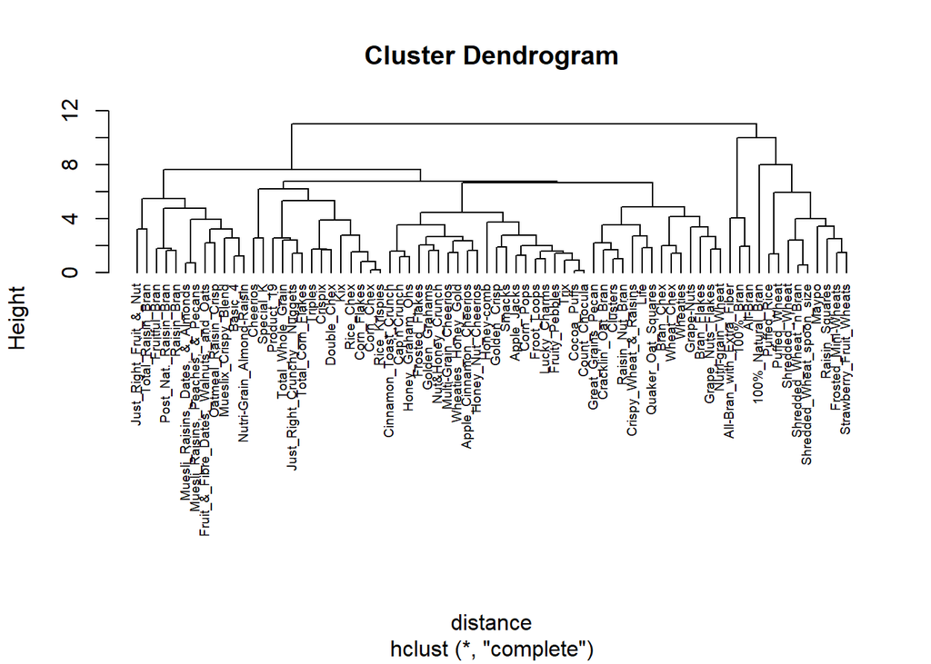

```r
distance <- dist(Cereals, method = "euclidean")
#Dissimilarity matrix
hier_clust <- hclust(distance, method = "complete")
#applied hierarchical clustering using complete linkage.
plot(hier_clust, cex = 0.6, hang = -1)
```

```r
#to plot the dendrogram.
```

> > > The clustering methods, such as single linkage, complete linkage, and average linkage, each have their own agglomerative coefficients.

```r
library(cluster)
```

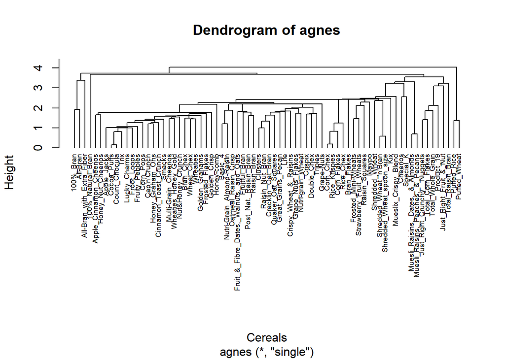

```r
hier_clust_single <- agnes(Cereals, method = "single")
pltree(hier_clust_single, cex = 0.6, hang = -1, main = " Dendrogram of agnes ")
```

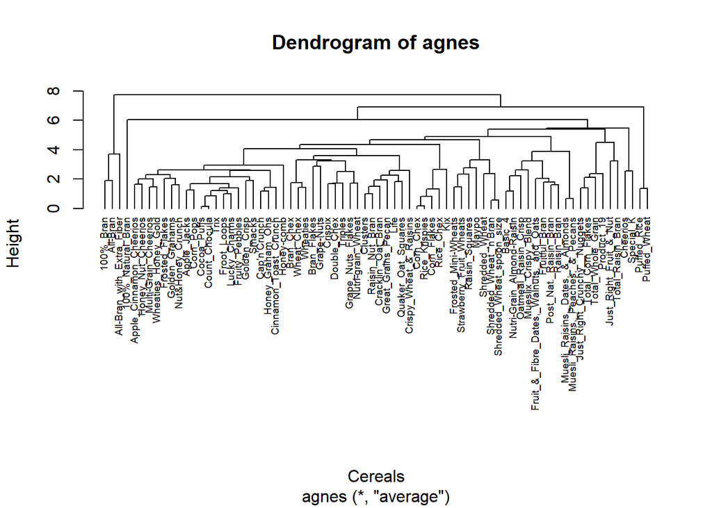

```r
hier_clust_avg <- agnes(Cereals, method = "average")
pltree(hier_clust_avg, cex = 0.6, hang = -1, main = " Dendrogram of agnes ")
```

> > To calculate the agnes coefficient for each approach.

```r
#install.packages("purrr")
library(purrr)
```

```r
m <- c( "average", "single", "complete", "ward")
# to asses the methods.
names(m) <- c( "average", "single", "complete", "ward")
# here function is used to compute coefficient.
ac <- function(x) {
  agnes(Cereals, method = x)$ac
}
map_dbl(m, ac)
```

```
##   average    single  complete      ward
## 0.7766075 0.6067859 0.8353712 0.9046042
```

> > > Ward is considered the most effective way to connect things, scoring a high 0.9046042 on the agglomerative coefficient.

Using the wards approach to visualize the dendrogram:

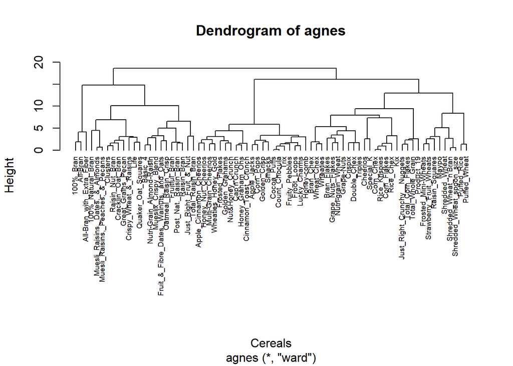

```r
hier_clust_Ward <- agnes(Cereals, method = "ward")
pltree(hier_clust_Ward, cex = 0.6, hang = -1, main = " Dendrogram of agnes ")
```

To Cut the dendrogram with cutree() so that we can find sub-groups (i.e. clusters):

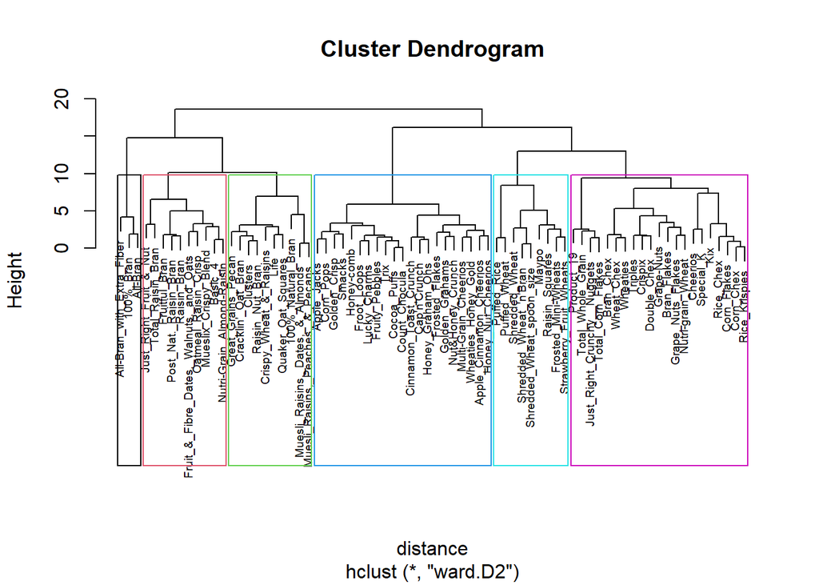

```r
distance <- dist(Cereals, method = "euclidean")
### to create the distance matrix.
hier_clust_Ward_clust <- hclust(distance, method = "ward.D2")
### ward's method for hierarchical clustering.
plot(hier_clust_Ward_clust, cex=0.6)
rect.hclust(hier_clust_Ward_clust, k=6, border = 1:6)
```

To examine how many data records have been categorized and that are allocated to clusters:

```r
# to cut decision tree into 6 groups
sub_groups <- cutree(hier_clust_Ward_clust, k=6)
# total no.of members in each single cluster.
table(sub_groups)
```

```
## sub_groups
##  1  2  3  4  5  6
##  3 10 21 10 21  9
```

Correlation Matrix:

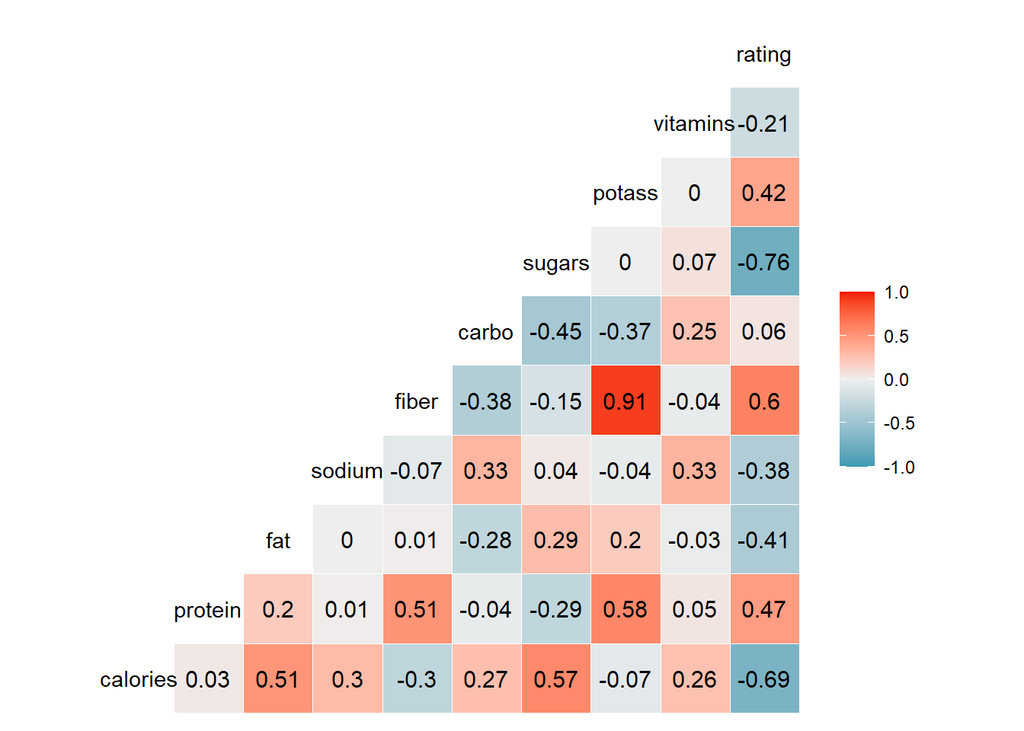

```r
#install.packages("GGally")
library(GGally)
library(dplyr)
Cereals_Data %>%
  select(calories, protein, fat, sodium, fiber, carbo, sugars, potass,vitamins,rating) %>%
  ggcorr(palette = "RdBu", label = TRUE, label_round =  2)
```

>>The correlation matrix helps us figure out if there’s a strong or weak connection between variables. It also allows us to calculate descriptive statistics for a better understanding.

The pvclust() function in the pvclust package helps assess the strength of clusters in hierarchical clustering using p-values from multiscale bootstrap resampling. Higher p-values indicate stronger support for clusters in the data. It’s important to note that pvclust groups columns, so transpose your data before using the function. Suzuki provides guidance on interpreting the results.

```r
#install.packages("pvclust")
library(pvclust)
fit.pv <- pvclust(Cereals, method.hclust = "ward.D2", method.dist = "euclidean")
```

```
## Bootstrap (r = 0.5)... Done.
## Bootstrap (r = 0.59)... Done.
## Bootstrap (r = 0.69)... Done.
## Bootstrap (r = 0.8)... Done.
## Bootstrap (r = 0.89)... Done.
## Bootstrap (r = 1.0)... Done.
## Bootstrap (r = 1.09)... Done.
## Bootstrap (r = 1.19)... Done.
## Bootstrap (r = 1.3)... Done.
## Bootstrap (r = 1.39)... Done.
```

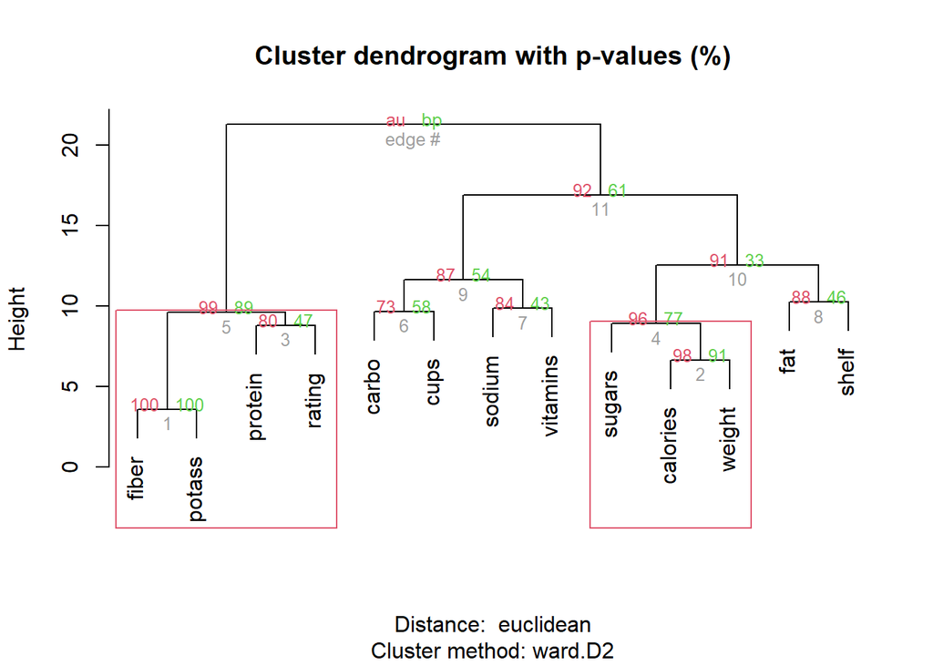

```r
plot(fit.pv)
#dendogram with p-values
pvrect(fit.pv, alpha =.95)
```

> > > In the initial clustering, we assess how stable each cluster is by looking at the average Jaccard coefficient across multiple bootstrap iterations. If a cluster’s stability rating is below 0.6, it is considered unstable. Ratings between 0.6 and 0.75 suggest that the cluster identifies a pattern in the data, but there isn’t strong agreement on which points should be grouped together. On the other hand, clusters with ratings above 0.85 are deemed exceptionally stable. 1.It’s most effective to enhance the Jaccard bootstrap on a cluster level. 2.Minimize the occurrence of dissolved clusters, and aim to enhance the recovery of clusters while maintaining proximity to the original number.

To Run Clusterboot()

```r
#install.packages("fpc")
library(fpc)
library(cluster)
kbest_p <- 6
cboot_hclust <- clusterboot(Cereals, clustermethod = hclustCBI, method = "ward.D2", k=kbest_p)
```

[output not shown]

[output cut: 45 more lines]

[output not shown]

```r
summary(cboot_hclust$result)
```

```
##               Length Class  Mode
## result         7     hclust list
## noise          1     -none- logical
## nc             1     -none- numeric
## clusterlist    6     -none- list
## partition     74     -none- numeric
## clustermethod  1     -none- character
## nccl           1     -none- numeric
```

```r
groups <- cboot_hclust$result$partition
head(data.frame(groups))
```

```
##                           groups
## 100%_Bran                      1
## 100%_Natural_Bran              2
## All-Bran                       1
## All-Bran_with_Extra_Fiber      1
## Apple_Cinnamon_Cheerios        3
## Apple_Jacks                    3
```

```r
cboot_hclust$bootmean
```

```
## [1] 0.9166988 0.5314793 0.9017605 0.6834444 0.6163358 0.7194252
```

```r
### vector for cluster stabilities.
```

```r
cboot_hclust$bootbrd
```

```
## [1]  9 58  0 30 29 32
```

```r
### to Count how many times each group was broken apart. The clusterboot() function usually runs 100 bootstrap iterations by default.
```

To Extract the clusters found by hclust()

```r
groups <- cutree(hier_clust_Ward_clust, k = 6)
print_cluster <- function(labels, k)
{
  for (i in 1:k)
    {
    print(paste("cluster",i))
    print(Cereals_Data[labels==i,c("mfr","calories","protein","fat","sodium","fiber","carbo","sugars","potass","vitamins","rating")])
  }
}
print_cluster(groups, 6)
```

```
## [1] "cluster 1"
##                           mfr calories protein fat sodium fiber carbo sugars
## 100%_Bran                   N       70       4   1    130    10     5      6
## All-Bran                    K       70       4   1    260     9     7      5
## All-Bran_with_Extra_Fiber   K       50       4   0    140    14     8      0
##                           potass vitamins   rating
## 100%_Bran                    280       25 68.40297
## All-Bran                     320       25 59.42551
## All-Bran_with_Extra_Fiber    330       25 93.70491
## [1] "cluster 2"
##                                   mfr calories protein fat sodium fiber carbo
## 100%_Natural_Bran                   Q      120       3   5     15   2.0   8.0
## Clusters                            G      110       3   2    140   2.0  13.0
## Cracklin'_Oat_Bran                  K      110       3   3    140   4.0  10.0
## Crispy_Wheat_&_Raisins              G      100       2   1    140   2.0  11.0
## Great_Grains_Pecan                  P      120       3   3     75   3.0  13.0
## Life                                Q      100       4   2    150   2.0  12.0
## Muesli_Raisins,_Dates,_&_Almonds    R      150       4   3     95   3.0  16.0
## Muesli_Raisins,_Peaches,_&_Pecans   R      150       4   3    150   3.0  16.0
## Quaker_Oat_Squares                  Q      100       4   1    135   2.0  14.0
## Raisin_Nut_Bran                     G      100       3   2    140   2.5  10.5
##                                   sugars potass vitamins   rating
## 100%_Natural_Bran                      8    135        0 33.98368
## Clusters                               7    105       25 40.40021
## Cracklin'_Oat_Bran                     7    160       25 40.44877
## Crispy_Wheat_&_Raisins                10    120       25 36.17620
## Great_Grains_Pecan                     4    100       25 45.81172
## Life                                   6     95       25 45.32807
## Muesli_Raisins,_Dates,_&_Almonds      11    170       25 37.13686
## Muesli_Raisins,_Peaches,_&_Pecans     11    170       25 34.13976
## Quaker_Oat_Squares                     6    110       25 49.51187
## Raisin_Nut_Bran                        8    140       25 39.70340
## [1] "cluster 3"
##                         mfr calories protein fat sodium fiber carbo sugars
## Apple_Cinnamon_Cheerios   G      110       2   2    180   1.5  10.5     10
## Apple_Jacks               K      110       2   0    125   1.0  11.0     14
## Cap'n'Crunch              Q      120       1   2    220   0.0  12.0     12
## Cinnamon_Toast_Crunch     G      120       1   3    210   0.0  13.0      9
## Cocoa_Puffs               G      110       1   1    180   0.0  12.0     13
## Corn_Pops                 K      110       1   0     90   1.0  13.0     12
```

[output cut: 111 more lines]

```
## Raisin_Squares              K       90       2   0      0     2    15      6
## Shredded_Wheat              N       80       2   0      0     3    16      0
## Shredded_Wheat_'n'Bran      N       90       3   0      0     4    19      0
## Shredded_Wheat_spoon_size   N       90       3   0      0     3    20      0
## Strawberry_Fruit_Wheats     N       90       2   0     15     3    15      5
##                           potass vitamins   rating
## Frosted_Mini-Wheats          100       25 58.34514
## Maypo                         95       25 54.85092
## Puffed_Rice                   15        0 60.75611
## Puffed_Wheat                  50        0 63.00565
## Raisin_Squares               110       25 55.33314
## Shredded_Wheat                95        0 68.23588
## Shredded_Wheat_'n'Bran       140        0 74.47295
## Shredded_Wheat_spoon_size    120        0 72.80179
## Strawberry_Fruit_Wheats       90       25 59.36399
```